# Tests multiples

### Test d’un contraste

Test d’un contraste : $H_0 : \mu_i-\mu_j = 0$ contre $H_1 : \mu_i-\mu_j \ne 0$.

On rejette $H_0$ Si la statistique de test $T$ associée est suffisamment grande. Supposons que $n$ soit grand, et que la loi de $T$ (student) puisse être approximée par une loi normale : sous $H_0$ : $T \sim \mathcal{N}(0,1)$

Alors on rejette $H_0$ si $|T| > 1.96$ et on a un risque de se tromper de 5% (risque de déclarer à tort que le contraste est significatif)

On va se placer dans le cas où $H_0$ est vraie, ie le contraste n’est pas significativement différent de 0.

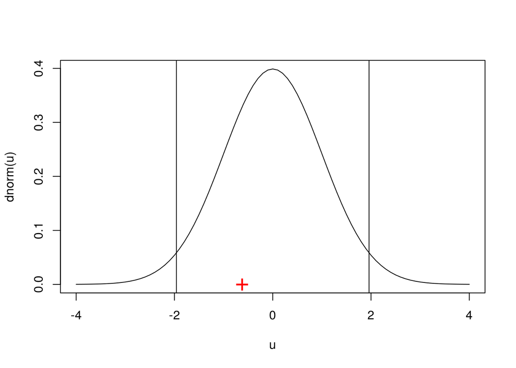

```r
set.seed(1)    # fixe alea pour que l'on ait tous la meme chose
u=seq(-4,4,by=0.1)
plot(u, dnorm(u), type='l')   #densité de la statistique de test T
# Simulons Tobs : on est sous HO donc c'est une réalisation d'une loi N(O,1)
Tobs= rnorm(1)
points(Tobs,0, col=2, pch="+", cex=2)  # on represente la valeur de Tobs sur l'axe des abscisses.
abline(v=-1.96)
abline(v=1.96)
```

Comme $|T_{obs}| \le 2$, on ne rejette pas $H_0$ : le contraste ne semble pas significativement différent de O. On ne se trompe pas ici (rappel : on a simulé $T$ sous $H_0$)

Recommençons cette simulation plusieurs fois :

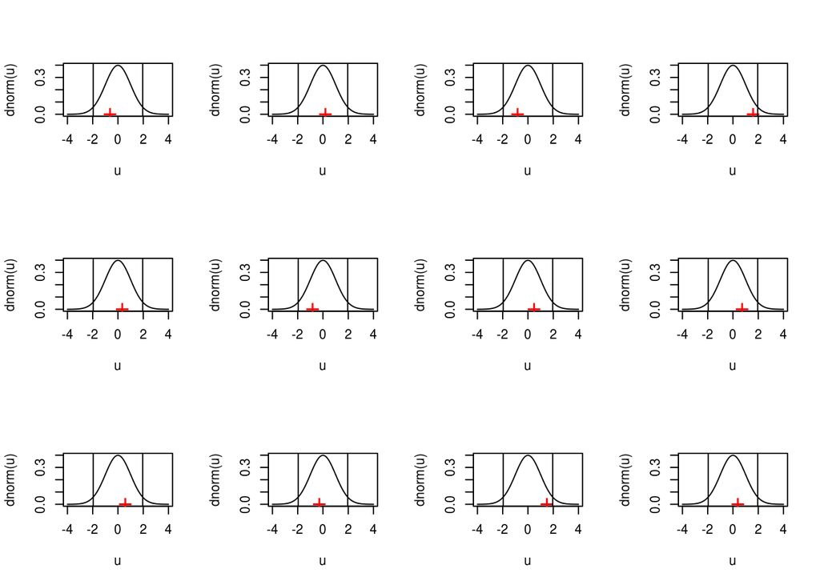

```r
set.seed(1)
par(mfrow=c(3,4))
for (nsim in 1:12)
{ u=seq(-4,4,by=0.1)
  plot(u, dnorm(u), type='l')
  Tobs= rnorm(1)
  points(Tobs,0, col=2, pch="+", cex=2)
  abline(v=-1.96)
  abline(v=1.96)
}
```

Sur ces 12 simulations, on ne s’est jamais trompé. En fait, cela peut arriver de déclarer à tort que le contraste est significativement différent de 0. C’est le risque de 1ère espèce, et ça peut arriver avec probabilité 5%. Donc sur 100 simulations, ça peut arriver 5 fois. (donc sur 12 simus environ $0.05*12=0.6$ fois)

# Tests multiples de m contrastes

Cette fois on va tester simultanément $m$ contrastes (si on a $I$ variétés et que l’on veut les tester 2 à 2, on a $m=\frac{I(I-1)}{2}$).

Pour chaque contraste, on va considérer le test de :

$H_{0,k}$ : le k-ème contraste est nul contre $H_{1,k}$ : le k-ème contraste est non nul.

Pour ce test, on a une statistique de test $T_k$ qui suit (si n grand) sous $H_{0,k}$ une loi normale centrée réduite. Si on fait le test de $H_{0,k}$ contre $H_{1,k}$ au niveau $5\%$, on va rejeter $H_{0,k}$ si $|T_k|$ est supérieur à 1.96.

Quelle est le risque de se tromper au moins une fois sur les $m$ tests, ie de déclarer à tort au moins un constraste significativement différent de 0 ? ie d’avoir au moins une des $m$ statistiques de test $|T_k|$ supérieure à 1.96 alors que le k-ème constraste est nul ?

On pose $H_0$ : les m contrastes sont nuls. Et on simule un cas où on est sous $H_0$.

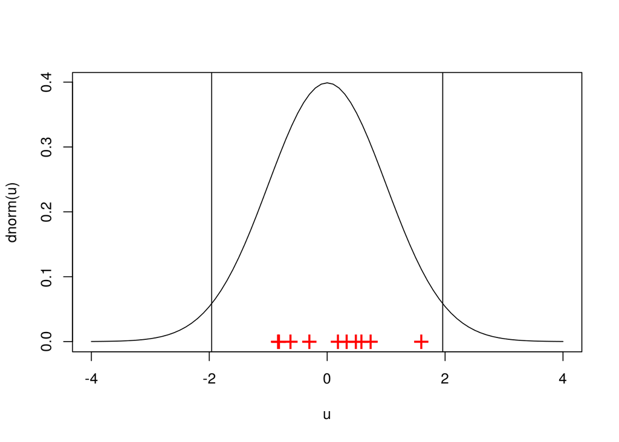

```r
set.seed(1)
m=10
u=seq(-4,4,by=0.1)
plot(u, dnorm(u), type='l')
# Simulons les m valeurs de Tobs : on est sous HO donc on a m réalisations d'une loi N(O,1)
Tobs= rnorm(m)
points(Tobs,rep(0,m), col=2, pch="+", cex=2)  # on represente les m valeurs de Tobs sur l'axe des abscisses.
abline(v=-1.96)
abline(v=1.96)
```

Ici on ne déclare aucun constraste significativement différent de 0 puisque les $m$ valeurs de $|T_k|$ sont inférieures à 1.96. Relançons la simulation précédente plusieurs fois :

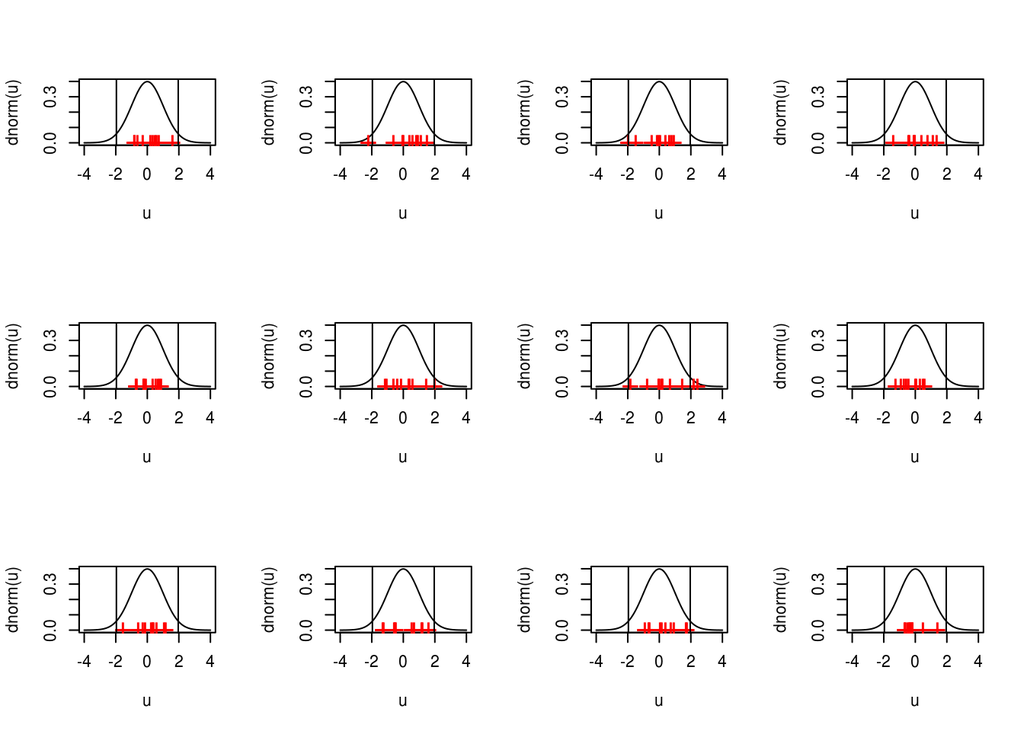

```r
set.seed(1)
m=10
u=seq(-4,4,by=0.1)
par(mfrow=c(3,4))
for (nsim in 1:12)
{  plot(u, dnorm(u), type='l')
  Tobs= rnorm(m)
  points(Tobs,rep(0,m), col=2, pch="+", cex=2)
  abline(v=-1.96)
  abline(v=1.96)
}
```

Dans 4 simulations sur les 12, on a trouvé, à tort, au moins un des $m$ contrastes significativement différents de 0. En effet, le risque de se tromper, ie le risque de déclarer au moins un contraste significativement différent de 0 alors qu’on est sous $H_0$, n’est plus contrôlé par $5\%$ mais par $m*5\%=0.5$. (et sur ces 12 simulations $4/12 = 0.33$).

L’idée est simplement qu’on fait $m$ tests, que pour chacun des tests, il peut arriver (avec risque de $5\%$) d’avoir à tort une statistique de test plus grande que le seuil. En faisant $m$ tests, le risque est simplement accru !

Donc lorsque l’on veut tester simulatanément $m$ contrastes tout en contrôlant le FWER (risque de faire au moins une fausse détection), il faut faire une correction de tests multiples, par exemple la correction de Bonferroni.

Une autre approche est de ne plus chercher à contrôler le FWER, mais à contrôler le FDR : le taux de faux positifs (contrastes déclarées significatifs à tort) parmi les hypothèses rejetées.